# Sobre o Uso da tabela da distribuição **t**

Markus Stein

8 September 2020

# Tabelas, tabelas, tabelas…

- Para que servem as tabelas?
- Cada número em uma tabela de probabilidade é resultado de inúmeros cálculos  
  (“Hoje em dia usamos computadores para encontrar esses números…”)

## Qual a diferença entre a tabela da distribuição **t (Student)** e da distribuição **Normal padrão**?

- Na tabela da distribuição **Normal padrão** precisamos somente definir o nível de significância $\alpha$, ou nível de confiança $1-\alpha$, para o problema….encontrar um valor tal que a probabilidade abaixo ou acima seja de interesse.
  - Na tabela da **Normal padrão** definimos a probabilidade de interesse no corpo da tabela e olhamos o valor correspondente na linha e coluna.
- Já na distribuição **t de Student** também precisamos calcular os graus de liberdade $\nu$, que é um parâmetro que depende do tamanho da amostra $n$, ou amostras $n_1$ e $n_2$ no caso de duas populações.  
  (*existe uma tabela igual a da normal padrão para cada grau de liberdade*)
- Então, para facilitar o uso da distribuição **t** foi criada uma tabela que apresenta valores , para específicos valores de $\nu$ e $\alpha$.
  - Na tabela da **t**, os valores associados a probabilidades estão no corpo da tabela, basta definirmos os graus de liberdade do problema $\nu$ e a probabilidade $\alpha$.

### Usando softwares para encontrar valores

- No software *R* podemos encontrar valores de $y$ tal que $P(Y < y) = \alpha$ usando as funções
  - ‘qnorm($\alpha$)’ para distribuição **Normal Padrão**,
  - ‘qt($\alpha, \nu$)’ para distribuição **t de Student**,
  - ‘qchisq($\alpha, \nu$)’ para a distribuição **Qui-QUadrado**.

em que $\nu$ são os graus de liberdade da distribuição.

Exemplos para se calcular $P(Y < y) = 0,975$:

- Para a distribuição *normal padrão** temos

```r
qnorm(0.975)
```

```
## [1] 1.959964
```

que corresponde na figura abaixo a $y=1.959964$

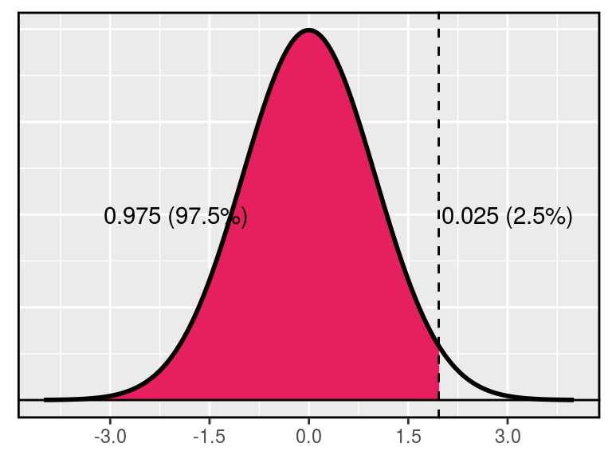

- Tente para a distribuição **t** e **qui-quadrado**,… . *(assuma $\nu = 15$ para **t** e **Qui-Quadrado**)*

### Aplicativos na internet

- (*em inglês*) Apps do livro ‘Statistics: The Art and Science of Learning from Data’
  - https://artofstat.com/web-apps
  - ver seção ‘Distributions: Explore Shapes & Find Probabilities’

## Referência

Livro online da plataforma [‘Probabilidade e Estatística (EAD)’](https://www.ufrgs.br/probabilidade-estatistica/livro/index.html) https://www.ufrgs.br/probabilidade-estatistica/livro/index.html

- No ‘Capítulo 3 - Distribuições de Variáveis Aleatórias’ ver Seções
  - 1.1.3 Tabela de probabilidade normal
  - 1.1.4 Exemplos de probabilidade